# HCl_adjusted

Carlos López Pleguezuelos

2022-05-24

The aim of this report is to show the step by step of the phenotype processing. Up to this point of the project thousands of radiomic features have been generated. Many raidomic features are related to the same biological feature of the lungs, so they can be clustered into the same object. By clustering we are not only reducing the dimensionality of the phenotype but also easing the interpretation of the radiomic features.

Radiomic features represent certain physical features of the ROI in the image. Therefore, by biologicaly interpreting them we can get many information about the lungs. The aim of this part of the project is to cluster the thousands of radiomic features into just a few that can be related to biological propierties of the lungs. The clusters then, can be used as the phenotype for further transcriptomic and genomic studies.

To cluster the radiomic features properly we have to eliminate the variance generated due to the sampling of the individuals: Image type and case-controls. In this sense, in prior steps of the project we have already adjusted data by the image type through the minimum voxel value. Also, we must adjust data for case-controls. In our dataset, the covariable that differenciates cases and controls is GOLD.

The GOLD criteria is a way of classify the airflow limitation in COPD and then indetify patients with the illness. In our particular case we will use the GOLD criteria to take case and controls apart. The GOLD classification differenciates the COPD patients in 4 groups: GOLD 1-mild, GOLD 2-moderate, GOLD 3-severe and GOLD 4-very severe.

```
  2   3   4
785 740 239
```

In the table above it is observed that all individuals included in the study show from moderate to very severe airflow limitation. Therefore we should assume that there are no controls in our cohort. Then, the hierarchical clustering method can be directly implemented with the dataset adjusted by the minimum voxel value.

The HCM can be implemented using different distance measures. Depending on the kind of data that are being analyzed a method can fit better than others. In our case, we will implement some distance measures that are commonly used. By looking at the results, we will decide which distance method better work with our data. However, we expect the pearson distance with the Ward’s algorithm to be the best since it is the distance measure that is implemented when clustering radiomic features [Cardiac Magnetic Resonance Radiomics Reveal Differential Impact of Sex, Age, and Vascular Risk Factors on Cardiac Structure and Myocardial].

### HCM with pearson distance measure

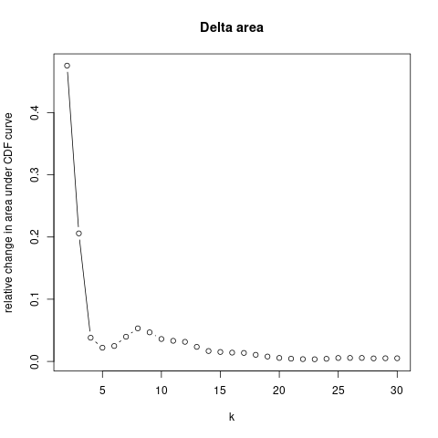

*Figure 1. Tracking plot*

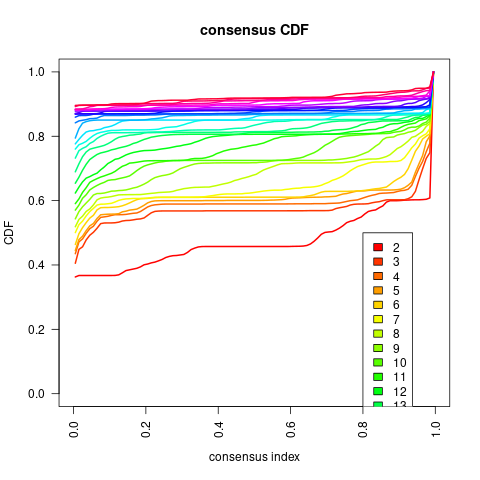

*Figure 1. Tracking plot*

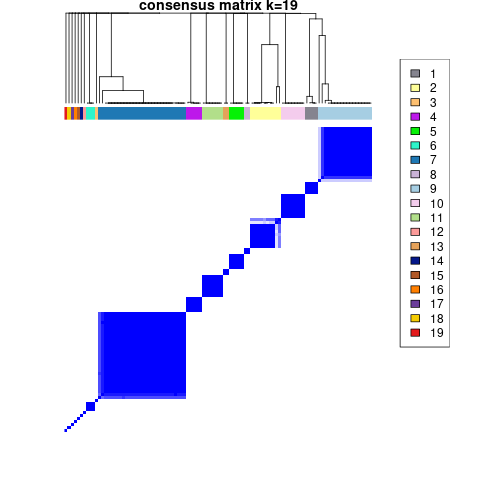

*Figure 1. Tracking plot*

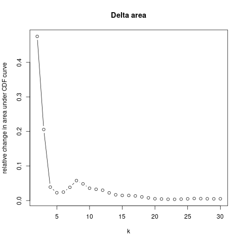

*Figure 1. Tracking plot*

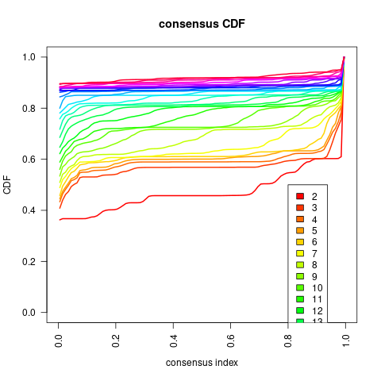

*Figure 1. Tracking plot*

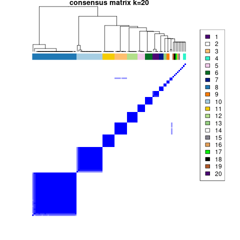

*Figure 1. Tracking plot*

### HCM with euclidean distance measure

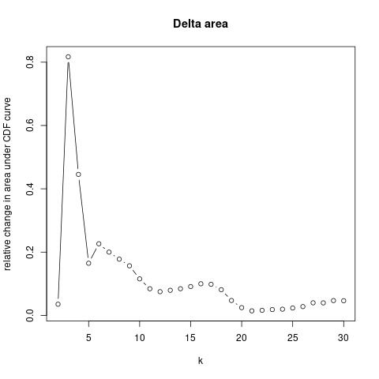

*Figure 1. Tracking plot*

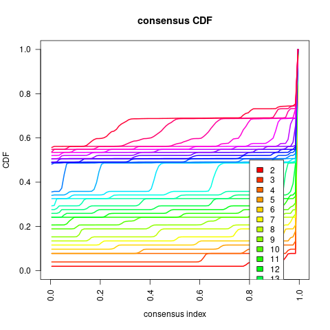

*Figure 1. Tracking plot*

It can be observed in the two plots above that the CDF is way lower when calculated with the Euclidean distance.

### HCM with maximum distance measure

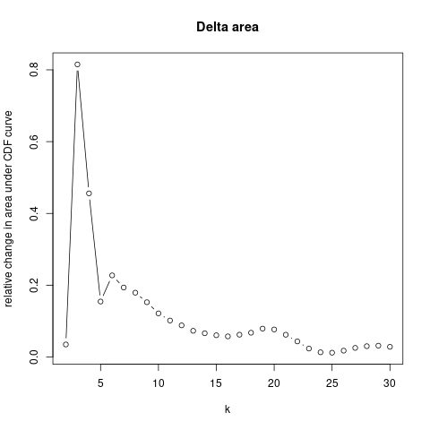

*Figure 1. Tracking plot*

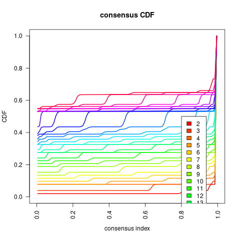

*Figure 1. Tracking plot*

Again, with the maximum distance the CDF shows up lower than the once observed when the HCL is run with the pearson distance measure.

### HCM with canberra distance measure

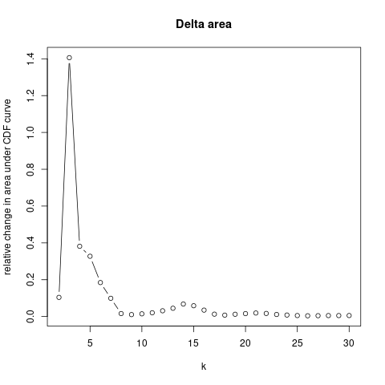

*Figure 1. Tracking plot*

[figure not shown]

*Figure 1. Tracking plot*

Again, it has been proven that pearson is the distance measure that best work with our data. The only difference when applying the Ward’s algorithm to the pearson measure distance is the order in which the clusters are grouped. Therefore, we can conclude that according with previous papers, the best way to cluster the radiomic features is with a Pearson measure distance and the Ward’s algorithm.

Now, is time to decide which is the number of clusters (k) that we should consider in the next steps of the research. As it has been explained in previous assays, the k clusters gather features that are related and, therefore, represent or quantify the same biological features of the lungs of the patients. Each cluster will be deeply analyzed in order to find out which lung feature is representing so then they will be implemented as the phenotype in the GWAS.

However, before, it is necessary to choose which number of clusters need to be considered. To do so, we have to look at the consensus Cumulative Distribution Function (CDF) plot and pick the numbber of clusters that leaves a wider Area Under the Curve (AUC). Also, we have to pay attention at the Delta Area Plot that shows the relative change in area under the CDF curve, in order to pick the K number from which the AUC does almost not change any more. Finally, will also look at the Consensus Matrices that may help to decide between close K numbers if the two plots mencioned before leave some doubts.

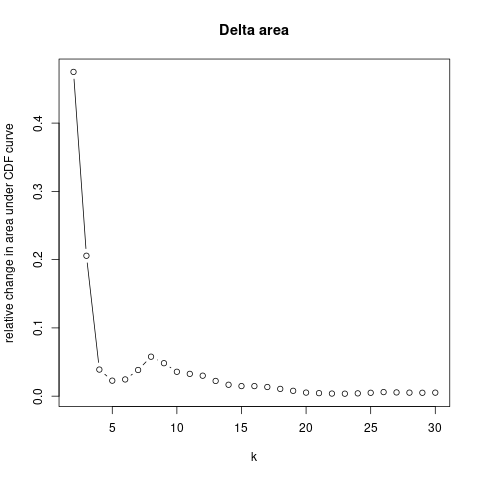

*Figure 1. Tracking plot*

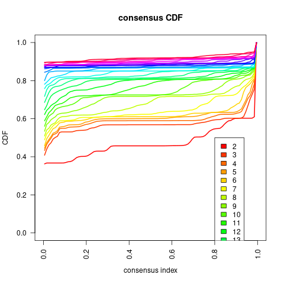

*Figure 1. Tracking plot*

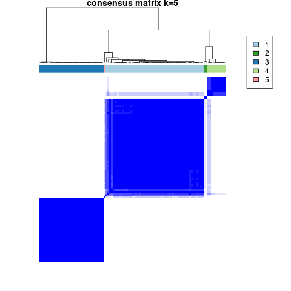

*Figure 1. Tracking plot*

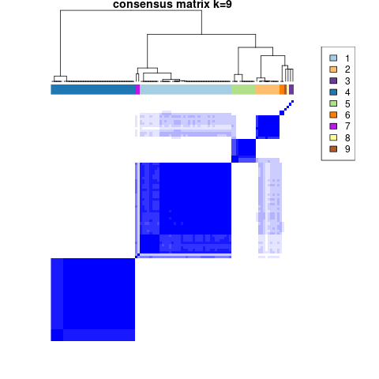

*Figure 1. Tracking plot*

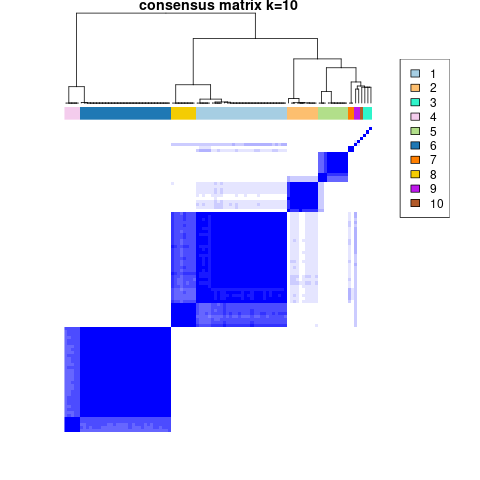

*Figure 1. Tracking plot*

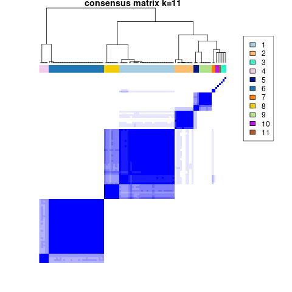

*Figure 1. Tracking plot*

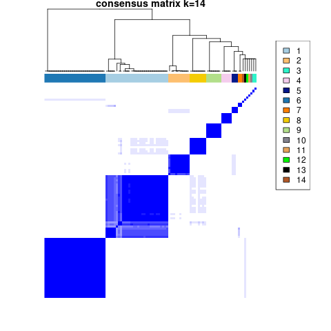

*Figure 1. Tracking plot*

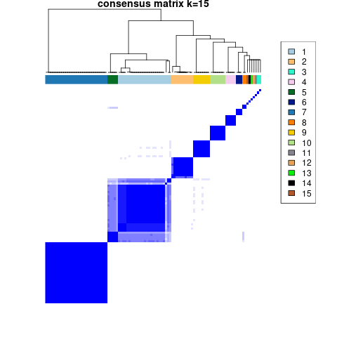

*Figure 1. Tracking plot*

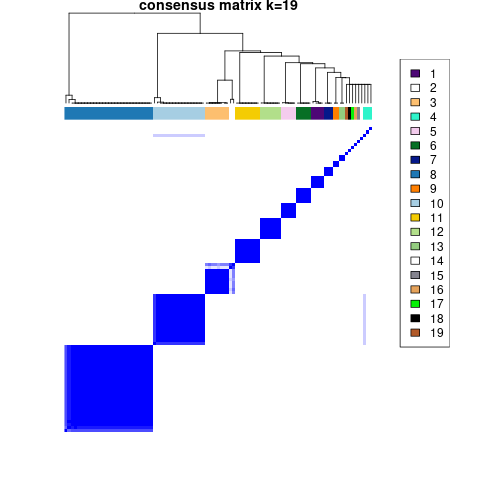

*Figure 1. Tracking plot*

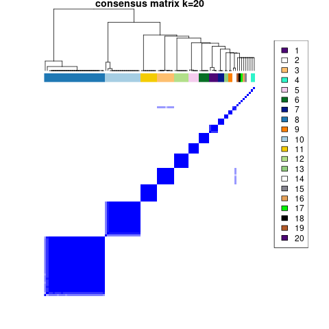

*Figure 1. Tracking plot*

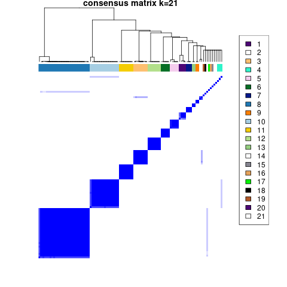

*Figure 1. Tracking plot*

### Interpretation of the clusters